# Analysis of retinal nerve crush RNA-seq data from Libby lab (updated)

Stanley Yang

1/15/2018

## Update Notes on analysis based on our discussion on 1-4-18:

- changed genotype of sample 42013 from Ddit3_Jun to Ddit3
- included the sex, generation, pen number information into PCA analysis
- added more the dimensional views of the MDS plot and PCA plot (Dim1 vs Dim2, Dim2 vs Dim3, Dim1 vs Dim3)
- added the comparisons of interaction of genotype and treatment among DJ, D, and J groups (a4, a5, a6)
- generated KEGG and GO analysis based on both glmTreat_1 list (DE genes regardless of how small the fold changes is) and glmTreat_1.2 list (DE gene for at least 1.2 fold change in either direction)

## Summary for all samples

| Group | N |
| --- | --- |
| Control.CONC | 5 |
| Control.DNT | 5 |
| Ddit3_Jun.CONC | 4 |
| Ddit3_Jun.DNT | 4 |
| Ddit3.CONC | 5 |
| Ddit3.DNT | 5 |
| Jun.CONC | 5 |
| Jun.DNT | 5 |

Have changed Genotype of sample 42013 from Ddit3_Jun to Ddit3

## Normalize and Filter the raw RNA-seq data

#### before filtering low-count genes

#### keep the genes that have more than 1 count per million (cpm) in at least 2 samples

#### normalize the filtered genes across all samples

|  | lib.size | norm.factors |
| --- | --- | --- |
| Ddit3_Jun.CONC.41891L | 22418619 | 0.987 |
| Ddit3_Jun.DNT.41891R | 25812270 | 0.973 |
| Ddit3_Jun.CONC.42011L | 13152421 | 1.022 |
| Ddit3_Jun.DNT.42011R | 20024287 | 1.002 |
| Ddit3.CONC.42013L | 24567299 | 0.992 |
| Ddit3.DNT.42013R | 27392590 | 0.990 |
| Ddit3_Jun.CONC.42014L | 20416988 | 0.990 |
| Ddit3_Jun.DNT.42014R | 25872129 | 0.983 |
| Ddit3.CONC.42142L | 18210742 | 0.992 |
| Ddit3.DNT.42142R | 22714707 | 0.992 |

[output cut: 28 more lines]

## Explore the data samples

#### MDS plot

to check the distance between each sample (Figure 1-3), similar to PCA plots

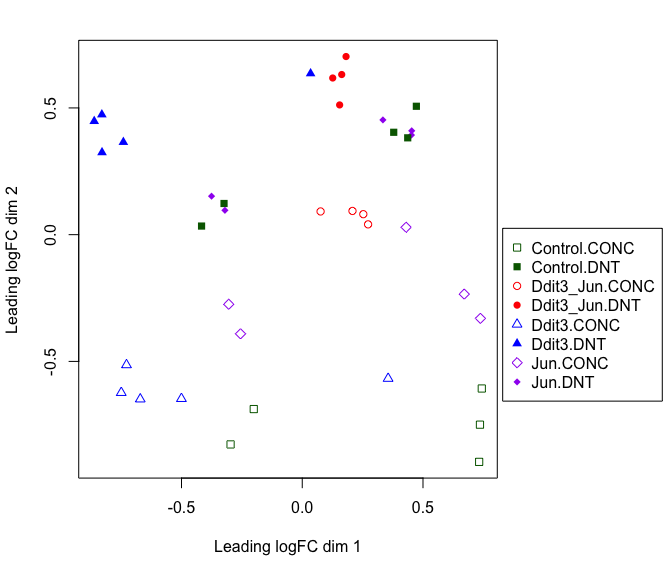

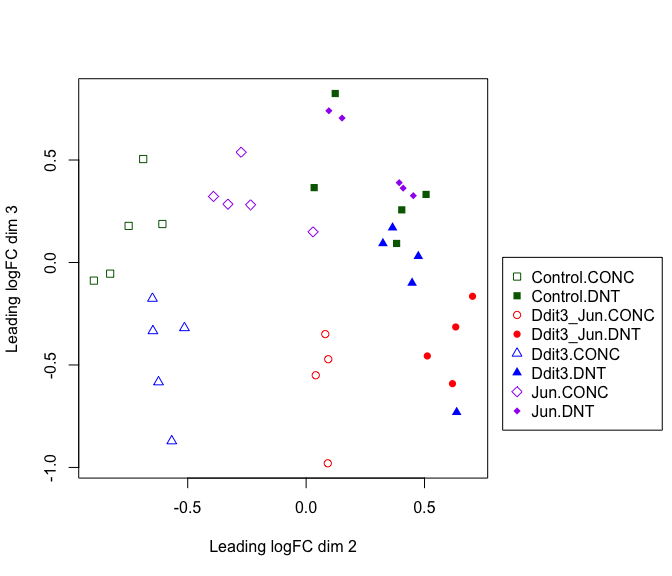

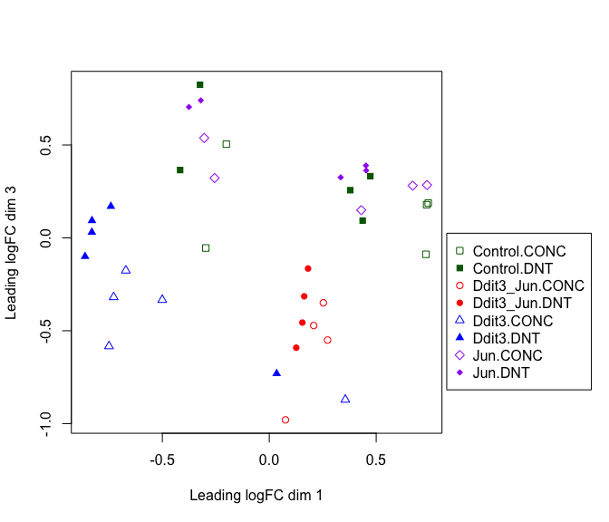

#### Principal Component Analysis (PCA)

scree plot to show all possible components for variance explained (Figure 4, 5)

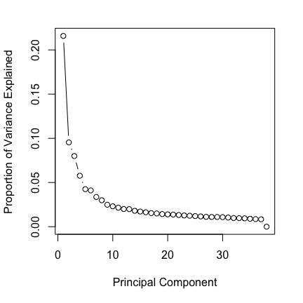

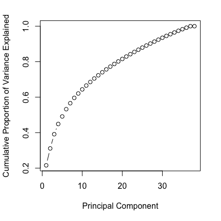

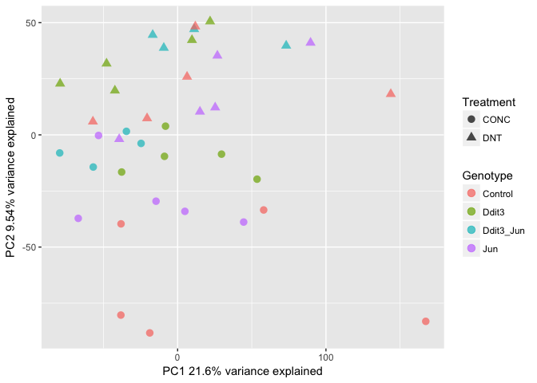

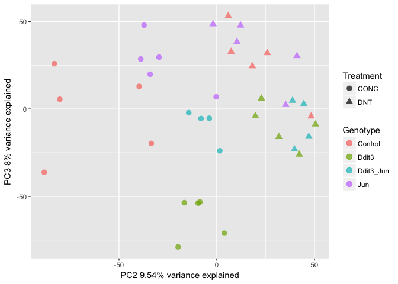

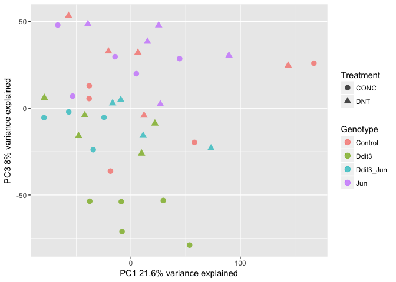

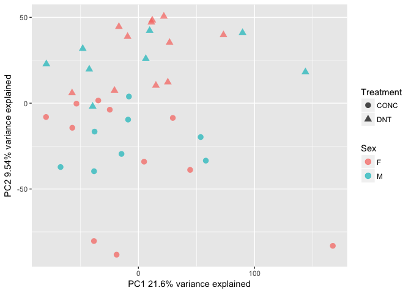

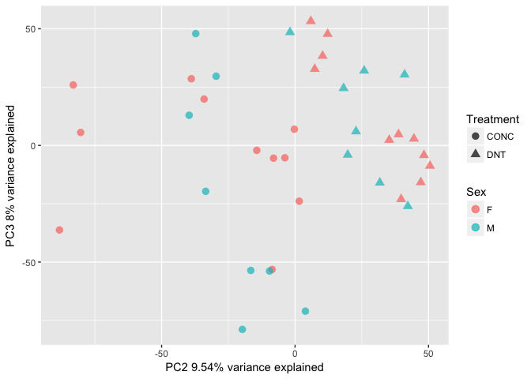

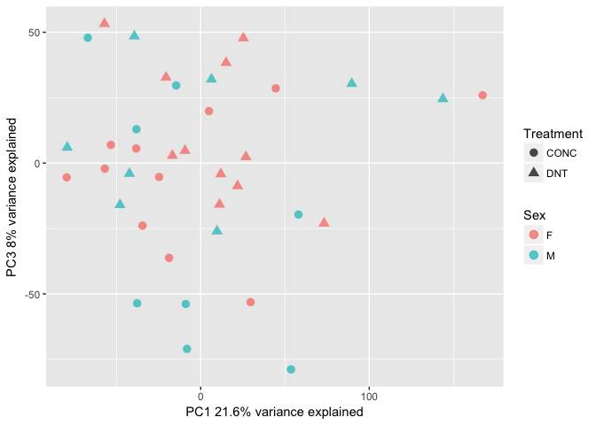

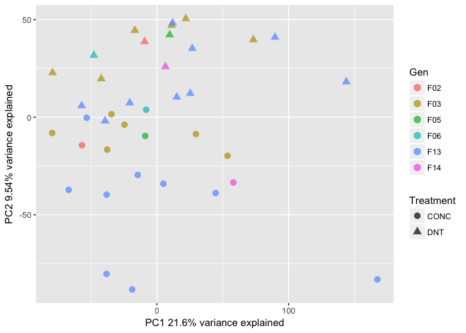

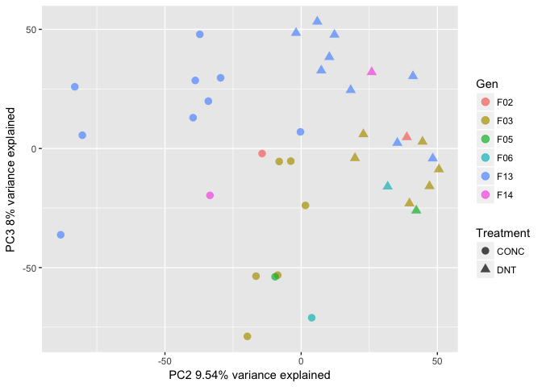

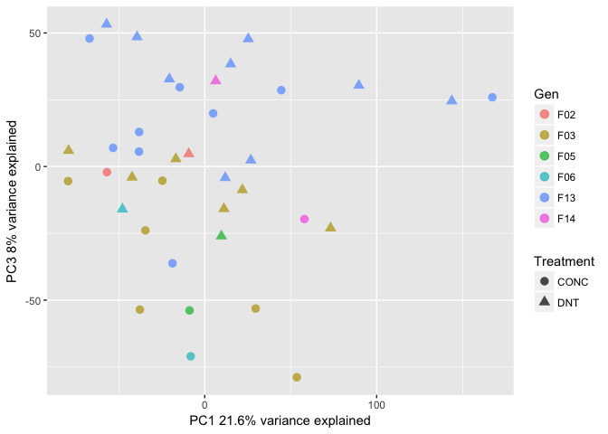

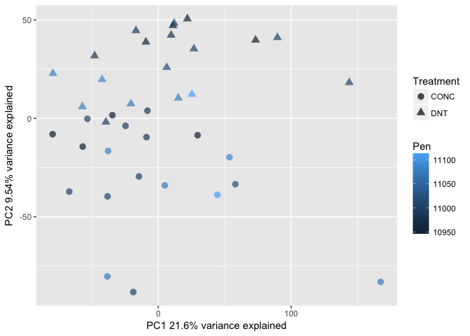

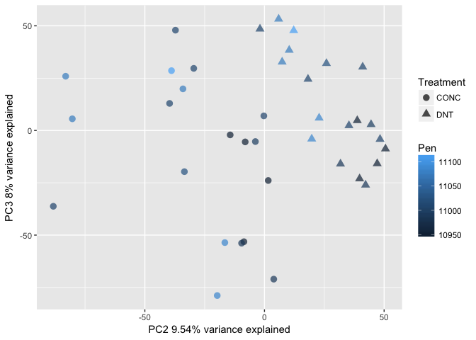

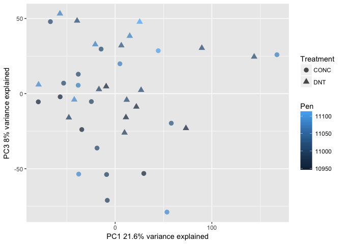

## Differential expression analysis

#### testing for differential expression

1. Methods for DE gene analysis
- I use generalized linear model based quasi-likelihood (QL) F-tests (glmQLFtest) instead of likelihood ratio test (LRT) for find DE genes as they give stricter error rate control by accounting for the uncertainty in dispersion estimation. (The old DE gene lists were made by LRT methods)
- There are two kinds of QL F-tests used in DE gene analysis, they are marked in the output files
  - glmTreat_1 : identifies differential expression based on statistical significance (*FDR < 0.05* as a cutoff) regardless of how small the difference might be. (1 means the FC = 1)
  - glmTreat_1.2 : identifies the differential expression fold changes are significantly greater than a specified fold change which is 1.2 in this case. (1.2 means FC=1.2, can be changed)
2. list of all the comparisions and their meanings:
- a1_DJvsC = (Ddit3_Jun.CONC - Ddit3_Jun.DNT) - (Control.CONC - Control.DNT)
  - The difference between Control mice and Ddit3-Jun mice in response to CONC crush treatment (interaction effect between genotype and treatment)
  - a1_DJvsC will be attached to the exported file names (as prefix) indicating this comparison. Same rule for the rest of the comparsions.
- a2_JvsC = (Jun.CONC - Jun.DNT) - (Control.CONC - Control.DNT)
  - The difference between Control mice and Jun mice in response to CONC crush treatment (interaction effect between genotype and treatment)
- a3_DvsC = (Ddit3.CONC - Ddit3.DNT) - (Control.CONC - Control.DNT)
  - The difference between Control mice and Ddit3 mice in response to CONC crush treatment (interaction effect between genotype and treatment)
- a4_DJvsJ = (Ddit3_Jun.CONC - Ddit3_Jun.DNT) - (Jun.CONC - Jun.DNT)
  - The difference between Ddit3_Jun mice and Jun mice in response to CONC crush treatment (interaction effect between genotype and treatment)
- a5_DJvsD = (Ddit3_Jun.CONC - Ddit3_Jun.DNT) - (Ddit3.CONC - Ddit3.DNT)
  - The difference between Ddit3_Jun mice and Ddit3 mice in response to CONC crush treatment (interaction effect between genotype and treatment)
- a6_DvsJ = (Ddit3.CONC - Ddit3.DNT) - (Jun.CONC - Jun.DNT)
  - The difference between Ddit3 mice and Jun mice in response to CONC crush treatment (interaction effect between genotype and treatment)
- a7_CONCvsDNT = Ddit3_Jun.CONC + Jun.CONC + Ddit3.CONC + Control.CONC - (Ddit3_Jun.DNT + Jun.DNT + Ddit3.DNT + Control.DNT)
  - The average differences between CONC and DNT treatment in mice of all genotypes
- a8_DJvsC.CONC = Ddit3_Jun.CONC - Control.CONC
  - The difference between Ddit3-Jun and Control mice with CONC treatment
- a9_JvsC.CONC = Jun.CONC - Control.CONC
  - The difference between Jun and Control mice with CONC treatment
- a10_DvsC.CONC = Ddit3.CONC - Control.CONC
  - The difference between Ddit3 and Control mice with CONC treatment
- a11_CONCvsDNT.DJ = Ddit3_Jun.CONC - Ddit3_Jun.DNT
  - The effect of CONC treatment on Ddit3-Jun mice
- a12_CONCvsDNT.J = Jun.CONC - Jun.DNT
  - The effect of CONC treatment on Jun mice
- a13_CONCvsDNT.D = Ddit3.CONC - Ddit3.DNT
  - The effect of CONC treatment on Ddit3 mice
- a14_CONCvsDNT.C = Control.CONC - Control.DNT
  - The effect of CONC treatment on Control mice
- a1_DJvsC-a2_JvsC-a3_DvsC
  - ANOVA-like tests to find any difference between Ddit3-Jun or Ddit3 or Jun mice and Control mice in response to CONC crush treatment (ANOVA-like tests on interaction effects between genotype and treatment)
- a8_DJvsC.CONC-a9_JvsC.CONC-a10_DvsC.CONC
  - ANOVA-like tests to find difference between Ddit3-Jun or Ddit3 or Jun mice and Control mice with CONC treatment
- a11_CONCvsDNT.DJ-a12_CONCvsDNT.J-a13_CONCvsDNT.D-a14_CONCvsDNT.C
  - ANOVA-like tests to find the effect of CONC treatment regardless of mouse genotype
3. Pathway analysis
- Gene ontology analysis:
  - all the genes from glmTreat lists with FDR<0.05 were put into gene ontology analysis.
  - The **Up** and **Down** columns indicate the number of genes within the GO term that are sigificantly up- and down-regulated in this differential expression comparison, respectively. The **P.Up** and **P.Down** columns contain the p-values for over-representation of the GO term in the up- and down-regulated genes, respectively.
  - GO terms with p-value less than 10<sup>-5</sup> were kept.
- KEGG pathway analysis
  - all the genes from glmTreat lists with FDR<0.05 were put into KEGG analysis.
  - same meaning for **Up** and **Down** ,and **P.Up** and **P.Down** columns as in GO terms
  - I kept p-value < 0.05 for KEGG analysis. May need p < 10<sup>-5</sup> for more stringent threthold.
- For detailed analysis, you are encoraged to put the gene lists of your interested comparison into david kegg pathway analysis tool. https://david.ncifcrf.gov/summary.jsp
- I can also help to analyze the gene set using Ingenuity Pathway Analysis (IPA) looking for gene network, transcrpition factor network etc, if you have interested comparisons.
4. Decode output files

#### heatmap visualization of sample clustering

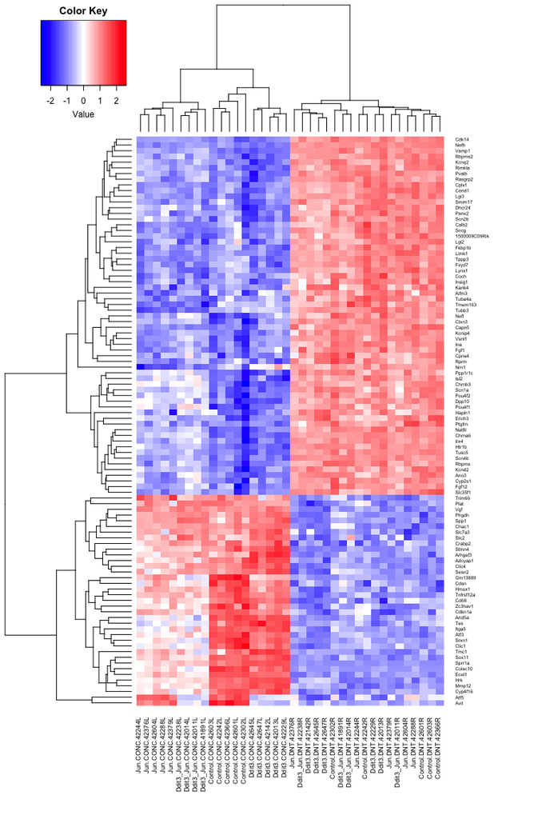